# CS 422 Section 01

Rohit Lakde

## 2.1 Problem 1: K-means clustering

##### Part loading all libraries and setting working directory

```r
setwd("/Users/rohit/Documents/")
library(cluster)
library(factoextra)
library(dplyr)
library(ggfortify)
library(ggplot2)
library(NbClust)
```

##### Part Whether transforming the data will help in any way or whether you can use the data in the form

```r
UserReview <- read.csv('buddymove_holidayiq.csv',header=T,sep=",")
UserReviewNoid <- UserReview
UserReviewNoid$User.Id <- NULL
UserReviewNoid.s <-scale(UserReviewNoid)
UserReviewNoid.s
```

[output not shown]

[output cut: 159 more lines]

> As row User.Id is non numeric nominal attribute so i am removing it, Apart from that range of sports column is 2 to 25 and for religious it is 50 to 203 so it is good to scale the data

##### Part 2.1 A How many clusters to select?Use fviz_nbclust() to determine the optimum number of clusters

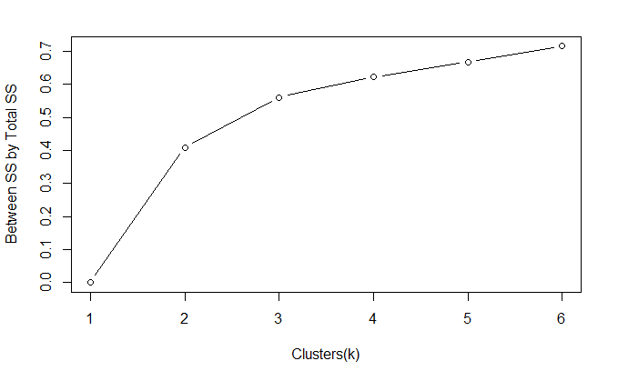

```r
k<-list()
betweenSSByTotalSS <- list()
for(i in 1:6){
k[[i]] <- kmeans(UserReviewNoid.s,i)
}
for(i in 1:6){
betweenSSByTotalSS[[i]]<-k[[i]]$betweenss/k[[i]]$totss
}
plot(1:6,betweenSSByTotalSS,type="b",ylab="Between SS by Total SS",xlab="Clusters(k)")
```

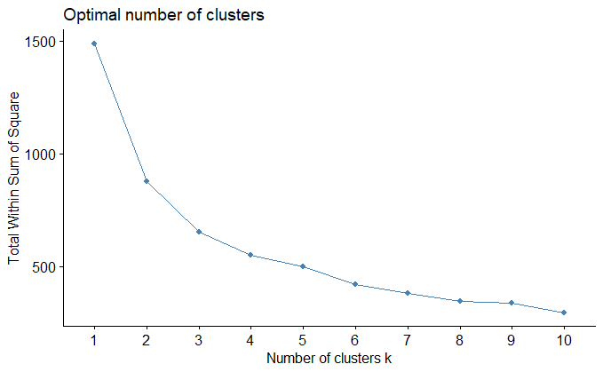

```r
fviz_nbclust(UserReviewNoid.s, kmeans, method="wss")
```

##### Part 2.1 B Run k-means clustering on the dataset to create that many clusters. Plot the clusters using fviz_cluster().

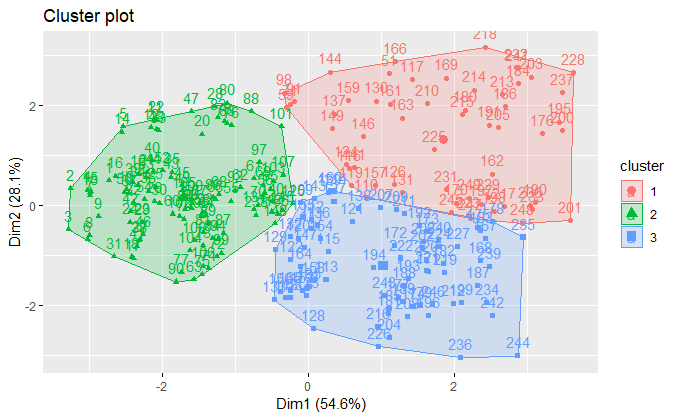

```r
Kmeansresult <- kmeans(UserReviewNoid.s,3)
fviz_cluster(Kmeansresult,data=UserReviewNoid.s)
```

> CLusters are created and plotted in above graphs.

##### Part 2.1 C How many observations are in each cluster?

```r
print(Kmeansresult['size'])
```

```
$size
[1]  59 111  79
```

##### Part 2.1 D What is the total SSE of the clusters?

```r
print(Kmeansresult$totss)
```

```
[1] 1488
```

##### Part 2.1 E What is the SSE of each cluster?

```r
print(Kmeansresult$withinss)
```

```
[1] 184.7223 213.5241 255.2145
```

> SSE of each cluster is 184.7223 213.5241 255.2145

##### Part 2.1 F Perform an analysis of each cluster

```r
for (cntr in 1:3){
 print(which(Kmeansresult$cluster == cntr))
 print("\n")
}
```

```
 [1]  51  59  71  91  98 110 116 117 119 124 126 130 131 137 141 144 146 149 157
[20] 159 161 162 163 166 169 170 176 180 184 186 190 191 195 197 198 200 201 203
[39] 205 210 213 214 215 217 218 223 225 228 229 230 231 232 233 237 241 245 247
[58] 248 249
[1] "\n"
  [1]   1   2   3   4   5   6   7   8   9  10  11  12  13  14  15  16  17  18  19
 [20]  20  21  22  23  24  25  26  27  28  29  30  31  32  33  34  35  36  37  38
 [39]  39  40  41  42  43  44  45  46  47  48  49  50  52  53  54  55  56  57  58
 [58]  60  61  62  63  64  65  66  67  68  69  70  72  73  74  75  76  77  78  79
 [77]  80  81  82  83  84  85  86  87  88  89  90  92  93  94  95  96  97  99 100
 [96] 101 102 103 104 105 106 107 108 125 134 140 142 145 148 156 238
[1] "\n"
 [1] 109 111 112 113 114 115 118 120 121 122 123 127 128 129 132 133 135 136 138
[20] 139 143 147 150 151 152 153 154 155 158 160 164 165 167 168 171 172 173 174
[39] 175 177 178 179 181 182 183 185 187 188 189 192 193 194 196 199 202 204 206
[58] 207 208 209 211 212 216 219 220 221 222 224 226 227 234 235 236 239 240 242
[77] 243 244 246
[1] "\n"
```

> If we have a look at above distribution of points then we will find out that clsters formed by method is nature and picnic and it makes sense people who goes to picnic loves nature, Another cluster formed by it is Theatre with shopping again it makes sense, SO i think it is working properly

## 2.2 Problem : Hierarchical clustering

##### Set seed equals to 1122 take 50 random records and scale data

```r
set.seed(1122)
holidayreview <- read.csv("buddymove_holidayiq.csv", header=T, sep=",")
holidayreview <- sample_n(holidayreview,50)
rownames(holidayreview) <- holidayreview[,1]
holidayreview <- holidayreview [ , -1]
holidayreview <- scale(holidayreview)
holidayreview
```

```
             Sports    Religious      Nature     Theatre    Shopping      Picnic
User 20  -0.8438782  0.206700087 -0.90689267 -1.32468472  0.03976440 -0.52154101
User 4   -1.2561965 -1.204012671 -1.05269535 -0.47224925 -0.87050500 -1.65894428
User 167  1.4925923  0.636047448  0.91564083  2.02822813  1.09376054  0.25522220
User 36  -0.9813176 -0.866668316 -0.83399133 -0.04603152 -0.46327921 -1.32604576
User 116  0.1181979  0.789385791 -0.39658329  0.20969913  0.39908127  0.33844683
User 115  0.3930768 -0.406653286  1.03714306 -0.35859119 -0.43932476  0.89327769
User 237  1.9049107  2.016092537 -0.76108999  0.35177170  2.89034488  1.03198540
User 43  -0.9813176 -0.621326967 -0.76108999 -1.01212505 -0.55909704 -0.27186712
User 71  -0.4315598  0.942724134 -1.49010339 -0.78480892  0.61467139  0.19973911
User 1   -1.2561965 -0.928003653 -1.00409445 -1.21102666 -1.06214066 -0.71573181
User 200  1.4925923  2.476107566  0.08942564  0.06762655  1.69262199  1.86423170
User 23  -0.8438782 -1.173345002 -0.05637704 -1.06895408 -1.11004957 -0.54928255
User 72  -0.4315598 -0.866668316  0.55113413  0.03921203 -1.03818620 -0.32735021
User 140 -0.1566810 -0.314650280  0.06512520 -0.10286055  0.15953669 -0.27186712
User 197  1.4925923  0.789385791  1.52315199  0.06762655  1.69262199  0.53263763
User 170  1.2177134  1.096062477  0.45393234  0.77798944  0.63862584  0.75456997
User 225  0.9428346  1.249400821 -0.51808552  0.77798944  1.33330512  0.22748065
User 35  -0.9813176 -0.437320955 -0.88259222 -1.04053957 -0.67886933 -0.24412558
User 17  -0.8438782 -1.480021689  0.25952877 -0.24493313 -1.39750307 -0.96540570
User 56  -0.4315598  0.022694075 -0.27508106 -0.64273635 -0.55909704  0.61586226
User 155 -0.1566810 -0.253314943  0.06512520  1.17579266  0.37512681 -0.49379947
User 145  0.1181979 -0.437320955  0.06512520  0.32335719  0.27930898 -0.57702410
User 53  -0.9813176 -0.866668316 -0.42088374 -1.23944118 -0.22373464 -0.99314724
User 240  0.9428346  0.206700087  0.91564083  1.88615555  1.09376054  0.08877294
User 37  -0.9813176 -0.621326967 -1.17419758  0.01079752 -1.18191295 -1.38152885
User 157  0.1181979  0.636047448 -0.03207659 -0.21651861  0.15953669  1.44810855
User 18  -0.8438782 -1.572024695  0.08942564 -0.10286055 -1.34959415 -0.99314724
User 98  -0.7064387  1.249400821 -1.36860115 -1.06895408  0.61467139  0.19973911
User 195  1.2177134  2.169430880 -0.76108999  1.20420718  2.05193885  1.72552398
User 185  0.9428346 -0.253314943  2.61667209 -0.21651861 -0.67886933  1.17069312
User 14  -1.1187570 -0.437320955 -1.61160562 -1.06895408 -0.22373464 -1.43701193
User 73  -0.4315598 -0.713329973  0.79413860 -0.92688150 -1.15795849 -0.21638404
User 217  1.4925923  1.126730146  1.28014753  0.63591686  1.45307741  0.78231152
User 224  0.9428346  0.636047448  1.03714306  1.74408297  0.49489910  0.25522220
User 38  -0.8438782 -1.296015677  0.18662743 -0.92688150 -1.34959415 -0.54928255
User 199  1.4925923  0.206700087  2.25216539  0.49384428 -0.43932476  1.58681627
User 76  -0.7064387  0.329370761 -1.36860115 -0.30176216  0.49489910 -0.79895644
User 239  1.4925923  0.513376773  1.15864530  2.73859102  0.85421596  0.08877294
User 168  1.4925923  0.666715116  1.64465423 -0.07444603 -0.19978018  2.14164713
User 139  0.1181979  0.636047448  0.08942564  0.06762655 -0.03209897  0.14425602
User 9   -1.1187570 -1.326683346 -0.29938150 -1.35309924 -1.39750307 -0.77121490
User 41  -0.8438782 -1.480021689 -0.05637704 -0.10286055 -1.18191295 -0.99314724
User 31  -0.9813176 -1.725363038 -0.12927838 -0.04603152 -1.46936644 -1.02088879
User 60  -0.7064387 -1.020006659 -0.27508106 -0.24493313 -0.55909704 -0.90992261
User 12  -1.1187570 -0.130644268 -1.46580294 -1.38151375 -0.24768909 -0.77121490
User 221  0.9428346  0.206700087  1.28014753  2.02822813  0.37512681  0.08877294
User 11  -1.1187570 -0.007973594 -1.61160562 -1.35309924 -0.22373464 -0.74347336
User 131  0.3930768  0.789385791  0.08942564  0.20969913  0.27930898  1.30940084
User 136  0.1181979  0.053361743  0.35673056  1.31786524  0.25535452 -0.79895644
User 248  1.2177134  0.789385791  0.69693681  0.77798944  0.75839813  2.55777028
attr(,"scaled:center")
   Sports Religious    Nature   Theatre  Shopping    Picnic
    11.14    107.26    120.32    111.62    112.34    120.80
attr(,"scaled:scale")
   Sports Religious    Nature   Theatre  Shopping    Picnic
 7.275932 32.607630 41.151507 35.193280 41.745883 36.047021
```

##### 2.2 A Run hierarchical clustering on the dataset using factoextra::eclust() method, use k=1 parameter to force a single cluster. Run the clustering algorithm for three linkages: single, complete, and average. Plot the dendogram associated with each linkage using fviz_dend(). Make sure that the labels (User IDs) are visible at the leafs of the dendogram.

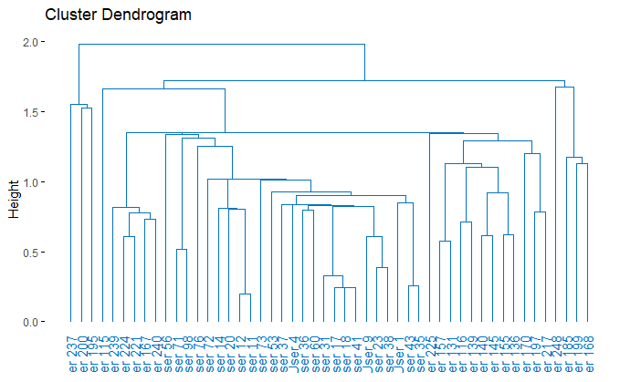

```r
selecteddata <- holidayreview
dendo.single <- eclust(selecteddata, "hclust" ,k=1, hc_method="single")
fviz_dend(dendo.single, palette="jco", as.ggplot=T)
```

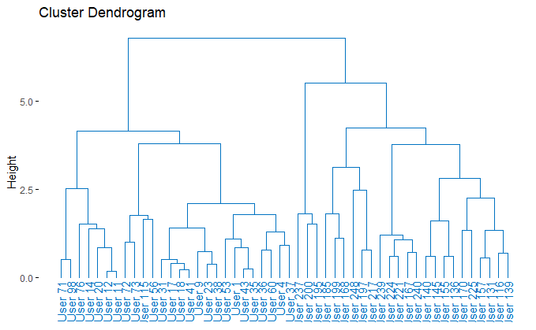

```r
dendo.complete <- eclust(selecteddata, "hclust" ,k=1, hc_method="complete")
fviz_dend(dendo.complete,palette="jco", as.ggplot=T)
```

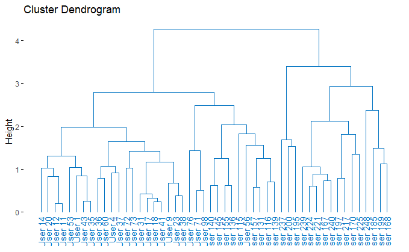

```r
dendo.average <- eclust(selecteddata, "hclust" ,k=1, hc_method="average")
fviz_dend(dendo.average, palette="jco", as.ggplot=T)
```

##### 2.2 B Examine each graph produced in (a) and understand the dendrogram. Notice which users are clustered together as two-singleton clusters (i.e., two users are clustered together because they are very close to each other in the attributes they share). For each linkage method, list all the two-singleton clusters. For instance, {User 43,User 35} form a two-singleton cluster in the average linkage method since they share a lot of the same characteristics

> Answers

For single linkage: {200,195},{224,221},{167,240},{71,98},{18,41},{12,11},{36,60},{23,38},{43,35},{157,131},{116,139},{140,145},{155,136},{197,217},{199,168}

For complete linkage: {71,98},{12,11},{72,73},{115,56},{18,41},{23,38},{43,35},{36,60},{4,37},{200,195},{199,168},{197,217},{224,221},{167,240},{140,145},{155,136},{170,225},{157,131},{116,139}

For average linkage: {12,11},{43,35},{36,60},{4,37},{72,73},{18,41},{23,38},{71,98},{140,145},{155,136},{157,131},{116,139},{200,195},{224,221},{167,240},{197,217},{170,225},{199,168}

##### 2.2 C We will now determine how many clusters to form. Let’s pick a hierarchical cluster that we will call pure,and let’s define purity as the linkage strategy that produces the least two-singleton clusters. Of the linkage methods you examined in (b), which linkage method would be considered pure by our definition?

> As number of two singleton clusters in single linkage are minimal that are 15,So single linkage method would be considered pure by given strategy.

##### 2.2 D Using the graph corresponding to the linkage method you chose in (c), draw a horizontal line at a height of 1.7. How many clusters would you have?

```r
clust17 <- cutree(dendo.single, h=1.7)
sprintf("We have %d Clusters", max(clust17))
```

```
[1] "We have 3 Clusters"
```

##### 2.2 E For the number of clusters you determined in (d), re-run hierarchical clustering across the three linkage strategies (single, average, and complete) with the value of k being the number of clusters you determined in (d). For each linkage strategy, find out its Silhouette index.

```r
newdendosingle <- eclust(holidayreview, "hclust" , k = max(clust17),  hc_method="single")
fviz_dend(newdendosingle, palette="jco", as.ggplot=T)
```

[output not shown]

```r
newdendocomplete <- eclust(holidayreview, "hclust", k = max(clust17), hc_method="complete")
fviz_dend(newdendosingle,palette="jco", as.ggplot=T)
```

[output not shown]

```r
newdendoaverage <- eclust(holidayreview, "hclust", k= max(clust17), hc_method="average")
fviz_dend(newdendosingle, palette="jco", as.ggplot=T)
```

[output not shown]

```r
stats <- fpc::cluster.stats(dist(holidayreview), cutree(newdendosingle, k=max(clust17)))
sprintf("For Single Link Silwidth %f", stats['avg.silwidth'])
```

```
[1] "For Single Link Silwidth 0.270304"
```

```r
stats <- fpc::cluster.stats(dist(holidayreview), cutree(newdendocomplete, k=max(clust17)))
sprintf("For complete Link Silwidth %f", stats['avg.silwidth'])
```

```
[1] "For complete Link Silwidth 0.353317"
```

```r
stats <- fpc::cluster.stats(dist(holidayreview), cutree(newdendoaverage, k=max(clust17)))
sprintf("For Average Link Silwidth %f", stats['avg.silwidth'])
```

```
[1] "For Average Link Silwidth 0.377551"
```

##### 2.2 F For each linkage strategy, determine the number of clusters that NbClust() suggests. Take a look at the method= parameter in NbClust() and pass in the linkage method, e.g.: NbClust(data, method=“single”).

```
NaNs produced
```

```
*** : The Hubert index is a graphical method of determining the number of clusters.
                In the plot of Hubert index, we seek a significant knee that corresponds to a
                significant increase of the value of the measure i.e the significant peak in Hubert
                index second differences plot.
```

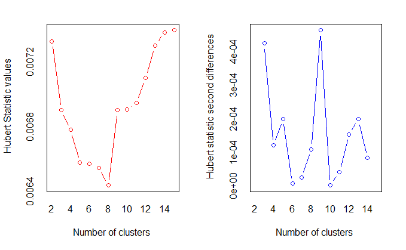

[output not shown]

[output cut: 56 more lines]

```
Value_Index          0   1.152      0  0.0553

$Best.partition
 User 20   User 4 User 167  User 36 User 116 User 115 User 237  User 43  User 71
       1        1        2        1        3        4        5        1        1
  User 1 User 200  User 23  User 72 User 140 User 197 User 170 User 225  User 35
       1        6        1        1        3        3        3        3        1
 User 17  User 56 User 155 User 145  User 53 User 240  User 37 User 157  User 18
       1        1        3        3        1        2        1        3        1
 User 98 User 195 User 185  User 14  User 73 User 217 User 224  User 38 User 199
       1        7        8        1        1        3        2        1        8
 User 76 User 239 User 168 User 139   User 9  User 41  User 31  User 60  User 12
       1        2        8        3        1        1        1        1        1
User 221  User 11 User 131 User 136 User 248
       2        1        3        3        9
```

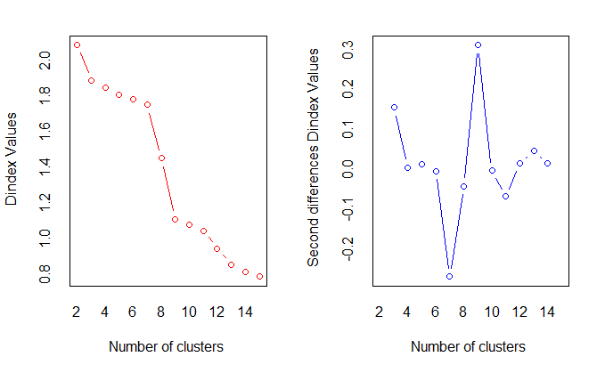

```r
NbClust(holidayreview,method="single")
```

```r
sprintf("For Single number of clusters are 9")
```

```
[1] "For Single number of clusters are 9"
```

```
*** : The Hubert index is a graphical method of determining the number of clusters.
                In the plot of Hubert index, we seek a significant knee that corresponds to a
                significant increase of the value of the measure i.e the significant peak in Hubert
                index second differences plot.
```

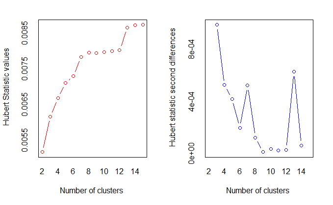

[output not shown]

[output cut: 57 more lines]

```
Value_Index          0  0.0855

$Best.partition
 User 20   User 4 User 167  User 36 User 116 User 115 User 237  User 43  User 71
       1        1        2        1        2        1        2        1        1
  User 1 User 200  User 23  User 72 User 140 User 197 User 170 User 225  User 35
       1        2        1        1        2        2        2        2        1
 User 17  User 56 User 155 User 145  User 53 User 240  User 37 User 157  User 18
       1        1        2        2        1        2        1        2        1
 User 98 User 195 User 185  User 14  User 73 User 217 User 224  User 38 User 199
       1        2        2        1        1        2        2        1        2
 User 76 User 239 User 168 User 139   User 9  User 41  User 31  User 60  User 12
       1        2        2        2        1        1        1        1        1
User 221  User 11 User 131 User 136 User 248
       2        1        2        2        2
```

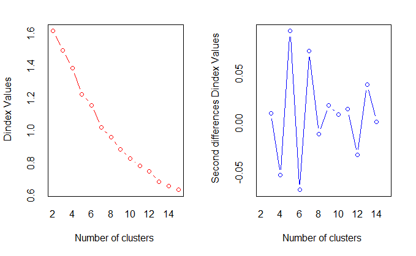

```r
NbClust(holidayreview,method="complete")
```

```r
sprintf("For Complete number of clusters are 2")
```

```
[1] "For Complete number of clusters are 2"
```

```
NaNs produced
```

```
*** : The Hubert index is a graphical method of determining the number of clusters.
                In the plot of Hubert index, we seek a significant knee that corresponds to a
                significant increase of the value of the measure i.e the significant peak in Hubert
                index second differences plot.
```

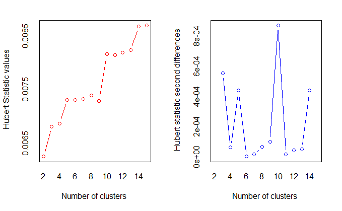

[output not shown]

[output cut: 57 more lines]

```
Value_Index          0  0.0815

$Best.partition
 User 20   User 4 User 167  User 36 User 116 User 115 User 237  User 43  User 71
       1        1        2        1        1        1        2        1        1
  User 1 User 200  User 23  User 72 User 140 User 197 User 170 User 225  User 35
       1        2        1        1        1        2        2        2        1
 User 17  User 56 User 155 User 145  User 53 User 240  User 37 User 157  User 18
       1        1        1        1        1        2        1        1        1
 User 98 User 195 User 185  User 14  User 73 User 217 User 224  User 38 User 199
       1        2        2        1        1        2        2        1        2
 User 76 User 239 User 168 User 139   User 9  User 41  User 31  User 60  User 12
       1        2        2        1        1        1        1        1        1
User 221  User 11 User 131 User 136 User 248
       2        1        1        1        2
```

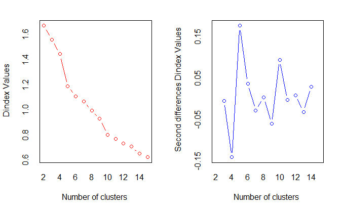

```r
NbClust(holidayreview,method="average")
```

```r
sprintf("For Average number of clusters are 2")
```

```
[1] "For Average number of clusters are 2"
```